2023-04-02

# Library

```r
library(tidyverse)
df <- read_csv("[DM02] data delirium latihan_1.csv")
df.2 <- read.csv2("[DM02] data delirium latihan_1.csv", sep = ",")
head(df)
```

```
## # A tibble: 6 x 29
##   jenisk~1  usia statu~2 pendi~3 peker~4 ruang~5 masuk~6 pembi~7 delir~8 tglmask
##      <dbl> <dbl>   <dbl>   <dbl>   <dbl>   <dbl>   <dbl>   <dbl>   <dbl> <chr>
## 1        2    68       1       3       1       3       1       3       0 4-Jan-~
## 2        2    64       1       4       2       1       1       2       0 4 mare~
## 3        2    61       2       3       1       3       1       2       0 16-Sep~
## 4        1    64       1       5       2       1       1       3       0 17 mar~
## 5        2    63       1       4       1       1       2       1       0 1-Feb-~
## 6        2    74       2       3       2       1       2       2       0 10-Nov~
## # ... with 19 more variables: tgldelir <chr>, tglplg <chr>,
## #   lamaperawatan <dbl>, kondisiplg <dbl>, timedelirium <dbl>, TIME <dbl>,
## #   STATUSDELIRIUM <dbl>, INFEKSIJUGA <dbl>, PENSTATUSFUNGSION <dbl>,
## #   GGNKOGNITIF <dbl>, KATALBUMIN <dbl>, HIPOKSIA <dbl>,
## #   GANGGUANMETABOLIK <dbl>, STROKRIWAYAT <dbl>, ANEMIA <dbl>,
## #   JENKELBARU <dbl>, KATUMURBARU <dbl>, JUMLAHOBATBARU <dbl>,
## #   PENYJANTUNGBARU <dbl>, and abbreviated variable names 1: jeniskelamin, ...
```

```r
head(df.2)
```

```
##   jeniskelamin usia statusnikah pendidikan pekerjaan ruangrwt masukdari
## 1            2   68           1          3         1        3         1
## 2            2   64           1          4         2        1         1
## 3            2   61           2          3         1        3         1
## 4            1   64           1          5         2        1         1
## 5            2   63           1          4         1        1         2
## 6            2   74           2          3         2        1         2
##   pembiayaan delirium       tglmask tgldelir         tglplg lamaperawatan
## 1          3        0      4-Jan-09                9-Jan-09             5
## 2          2        0  4 maret 2009           11 maret 2009             7
## 3          2        0     16-Sep-09               29-Sep-09            13
## 4          3        0 17 maret 2010                9-Apr-10            32
## 5          1        0      1-Feb-10                5-Feb-10             4
## 6          2        0     10-Nov-10               19-Nov-11             9
##   kondisiplg timedelirium TIME STATUSDELIRIUM INFEKSIJUGA PENSTATUSFUNGSION
```

[output cut: 20 more lines]

```r
str(df.2)
```

```
## 'data.frame':    457 obs. of  29 variables:
##  $ jeniskelamin     : int  2 2 2 1 2 2 2 1 2 2 ...
##  $ usia             : int  68 64 61 64 63 74 65 85 67 60 ...
##  $ statusnikah      : chr  "1" "1" "2" "1" ...
##  $ pendidikan       : int  3 4 3 5 4 3 2 4 4 4 ...
##  $ pekerjaan        : int  1 2 1 2 1 2 1 3 2 1 ...
##  $ ruangrwt         : int  3 1 3 1 1 1 1 1 1 3 ...
##  $ masukdari        : int  1 1 1 1 2 2 1 1 2 2 ...
##  $ pembiayaan       : int  3 2 2 3 1 2 1 2 2 3 ...
##  $ delirium         : int  0 0 0 0 0 0 1 0 0 0 ...
##  $ tglmask          : chr  "4-Jan-09" "4 maret 2009" "16-Sep-09" "17 maret 2010" ...
##  $ tgldelir         : chr  " " " " " " " " ...
##  $ tglplg           : chr  "9-Jan-09" " 11 maret 2009" "29-Sep-09" "9-Apr-10" ...
##  $ lamaperawatan    : int  5 7 13 32 4 9 NA 4 3 12 ...
##  $ kondisiplg       : int  1 1 1 1 1 1 2 3 1 1 ...
##  $ timedelirium     : int  NA NA NA NA NA NA 3 NA NA NA ...
##  $ TIME             : int  5 7 13 14 4 9 3 4 3 12 ...
##  $ STATUSDELIRIUM   : int  0 0 0 0 0 0 1 0 0 0 ...
##  $ INFEKSIJUGA      : int  1 1 1 1 0 1 1 2 1 1 ...
##  $ PENSTATUSFUNGSION: int  0 0 0 NA 0 NA NA 1 0 0 ...
##  $ GGNKOGNITIF      : int  0 0 NA NA 0 0 NA 1 NA 0 ...
##  $ KATALBUMIN       : int  0 0 NA 0 1 NA NA 1 NA 0 ...
##  $ HIPOKSIA         : int  1 0 0 1 0 NA NA 0 NA 0 ...
##  $ GANGGUANMETABOLIK: int  1 NA 1 1 0 0 0 1 NA 1 ...
##  $ STROKRIWAYAT     : int  0 0 0 0 0 0 1 0 0 0 ...
##  $ ANEMIA           : int  1 0 0 1 0 0 0 1 0 0 ...
##  $ JENKELBARU       : int  0 0 0 1 0 0 0 1 0 0 ...
##  $ KATUMURBARU      : int  0 0 0 0 0 1 0 2 0 0 ...
##  $ JUMLAHOBATBARU   : int  1 2 1 1 1 0 0 0 0 1 ...
##  $ PENYJANTUNGBARU  : int  1 0 1 1 0 0 0 0 0 1 ...
```

```r
glimpse(df.2)
```

```
## Rows: 457
## Columns: 29
## $ jeniskelamin      <int> 2, 2, 2, 1, 2, 2, 2, 1, 2, 2, 1, 1, 1, 2, 2, 1, 1, 2~
## $ usia              <int> 68, 64, 61, 64, 63, 74, 65, 85, 67, 60, 69, 68, 70, ~
## $ statusnikah       <chr> "1", "1", "2", "1", "1", "2", "1", "1", "1", "1", "1~
## $ pendidikan        <int> 3, 4, 3, 5, 4, 3, 2, 4, 4, 4, 5, 4, 3, 2, 4, 3, 4, 5~
## $ pekerjaan         <int> 1, 2, 1, 2, 1, 2, 1, 3, 2, 1, 3, 2, 2, 1, 2, 2, 2, 3~
## $ ruangrwt          <int> 3, 1, 3, 1, 1, 1, 1, 1, 1, 3, 1, 1, 1, 1, 1, 1, 1, 1~
## $ masukdari         <int> 1, 1, 1, 1, 2, 2, 1, 1, 2, 2, 1, 1, 2, 1, 1, 1, 1, 1~
## $ pembiayaan        <int> 3, 2, 2, 3, 1, 2, 1, 2, 2, 3, 1, 2, 2, 1, 2, 3, 2, 1~
## $ delirium          <int> 0, 0, 0, 0, 0, 0, 1, 0, 0, 0, 0, 0, 1, 1, 1, 0, 0, 1~
## $ tglmask           <chr> "4-Jan-09", "4 maret 2009", "16-Sep-09", "17 maret 2~
## $ tgldelir          <chr> " ", " ", " ", " ", " ", " ", "12-Jan-09", " ", " ",~
## $ tglplg            <chr> "9-Jan-09", " 11 maret 2009", "29-Sep-09", "9-Apr-10~
## $ lamaperawatan     <int> 5, 7, 13, 32, 4, 9, NA, 4, 3, 12, 15, 7, NA, NA, NA,~
```

[output cut: 16 more lines]

```r
df.2 <- df.2 %>%
  mutate(
    statusnikah = as.numeric(statusnikah)
  )
summary(df.2)
```

```
##   jeniskelamin        usia         statusnikah      pendidikan
##  Min.   :1.000   Min.   : 60.00   Min.   :1.000   Min.   :1.000
##  1st Qu.:1.000   1st Qu.: 64.00   1st Qu.:1.000   1st Qu.:2.000
##  Median :1.000   Median : 68.00   Median :1.000   Median :3.000
##  Mean   :1.475   Mean   : 69.56   Mean   :1.389   Mean   :3.202
##  3rd Qu.:2.000   3rd Qu.: 74.00   3rd Qu.:2.000   3rd Qu.:4.000
##  Max.   :2.000   Max.   :100.00   Max.   :3.000   Max.   :5.000
##                                                   NA's   :2
##    pekerjaan        ruangrwt       masukdari       pembiayaan
##  Min.   :1.000   Min.   :1.000   Min.   :1.000   Min.   :1.000
##  1st Qu.:1.000   1st Qu.:1.000   1st Qu.:1.000   1st Qu.:1.000
##  Median :2.000   Median :1.000   Median :1.000   Median :2.000
##  Mean   :2.158   Mean   :1.597   Mean   :1.201   Mean   :1.952
##  3rd Qu.:3.000   3rd Qu.:2.000   3rd Qu.:1.000   3rd Qu.:2.000
##  Max.   :4.000   Max.   :4.000   Max.   :2.000   Max.   :3.000
##
##     delirium        tglmask            tgldelir            tglplg
##  Min.   :0.0000   Length:457         Length:457         Length:457
##  1st Qu.:0.0000   Class :character   Class :character   Class :character
##  Median :0.0000   Mode  :character   Mode  :character   Mode  :character
##  Mean   :0.2123
##  3rd Qu.:0.0000
##  Max.   :1.0000
##
##  lamaperawatan     kondisiplg     timedelirium         TIME
##  Min.   : 0.00   Min.   :1.000   Min.   : 1.000   Min.   : 0.000
##  1st Qu.: 5.00   1st Qu.:1.000   1st Qu.: 2.000   1st Qu.: 4.000
##  Median : 8.00   Median :1.000   Median : 3.000   Median : 7.000
##  Mean   :10.41   Mean   :1.431   Mean   : 6.144   Mean   : 7.742
##  3rd Qu.:13.25   3rd Qu.:2.000   3rd Qu.: 8.000   3rd Qu.:12.000
##  Max.   :75.00   Max.   :3.000   Max.   :36.000   Max.   :14.000
##  NA's   :97                      NA's   :360
##  STATUSDELIRIUM    INFEKSIJUGA   PENSTATUSFUNGSION  GGNKOGNITIF
##  Min.   :0.0000   Min.   :0.00   Min.   :0.0000    Min.   :0.0000
##  1st Qu.:0.0000   1st Qu.:1.00   1st Qu.:0.0000    1st Qu.:0.0000
##  Median :0.0000   Median :1.00   Median :0.0000    Median :0.0000
##  Mean   :0.1882   Mean   :0.93   Mean   :0.2459    Mean   :0.2024
##  3rd Qu.:0.0000   3rd Qu.:1.00   3rd Qu.:0.0000    3rd Qu.:0.0000
##  Max.   :1.0000   Max.   :2.00   Max.   :1.0000    Max.   :1.0000
##                                  NA's   :26        NA's   :37
```

[output cut: 9 more lines]

```
##  Min.   :0.0000   Min.   :0.0000   Min.   :0.0000   Min.   :0.0000
##  1st Qu.:0.0000   1st Qu.:0.0000   1st Qu.:0.0000   1st Qu.:0.0000
##  Median :0.0000   Median :1.0000   Median :0.0000   Median :1.0000
##  Mean   :0.3676   Mean   :0.5252   Mean   :0.5427   Mean   :0.6302
##  3rd Qu.:1.0000   3rd Qu.:1.0000   3rd Qu.:1.0000   3rd Qu.:1.0000
##  Max.   :1.0000   Max.   :1.0000   Max.   :2.0000   Max.   :2.0000
##
##  PENYJANTUNGBARU
##  Min.   :0.0000
##  1st Qu.:0.0000
##  Median :0.0000
##  Mean   :0.5514
##  3rd Qu.:1.0000
##  Max.   :2.0000
##
```

Catatan : - “Jenis kelamin” udah lengkap dan udah bener, laki dan perempuan - “Usia” seharusnya gada yang aneh, udah make sense, dari 60 - 100, kalau mau lihat usia persebaran usianya ada di bawah - “Status Nikah” Ada yang error (noisy), status nikah 2.7 –> record ke 366 - “Pendidikan”, ada yang NA (2) –> record ke 307 da 315 - “Pekerjaan”, aman - “Ruang Rawat”, aman - “Masuk Dari, aman -”Pembiayaan”, aman harusnya - “delirium”, aman harusny a - “tgl.mask”, –> BANYAK ERRORNYA HHHHH . inkonsistensi format tanggalnya. inkonsistensi dalam format –> ada yang double spasi . typo –> “okt” jadi “0kt” –> menyebabkan salah dalam pas mau di split (row 144) . typo nulias tahun, contoh : 1010 dan 201 - “tgl.keluar” –> Masalahnya kurang lebih sama kaya di tanggal masuk, inkonsistensi yang sangat beragam - “tglderilium” –> kurang lebih bermasalah di inkonsistensi penulisan, untuk hubungan dengan variabel derilium tetap aman - “lamaperawatan” –> terdapat 97 missing value - “kondisiplg” –> gada masalah yang berarti (gada missinig value, gada nilai yang aneh) - “time derililum” –> ada masalah missing value - “TIME”, aman - “STATUSDELIRIUM”, aman –> tetapi ada indikasi tidak konsisten dengan variabel “delirium” tapi tidak bisa diputuskan karena kurangnya informasi - “INFEKSIJUGA”, aman - “PENSTATUSFUNGSION” –> missing value - “GGNKOGNITIF” –> missing value - “KATALBUMIN” –> missing value - “HIPOKSIA” –> missing value - “GANGGUANMETABOLIK” –> missing value - “STROKRIWAYAT”, aman - “ANEMIA”, aman - “JENKELBARU”, aman - “KATUMURBARU”, aman - “JUMLAHOBATBARU”, aman - “PENYJANTUNGBARU”,

```r
df.2 %>%
  count(usia)
```

```
##    usia  n
## 1    60 29
## 2    61 21
## 3    62 24
## 4    63 25
## 5    64 23
## 6    65 37
## 7    66 18
## 8    67 24
## 9    68 28
## 10   69 26
## 11   70 27
## 12   71 23
## 13   72 19
## 14   73 12
```

[output cut: 21 more lines]

# Cek Jenis Kelamin

```r
df.2 %>%
  count(jeniskelamin)
```

```
##   jeniskelamin   n
## 1            1 240
## 2            2 217
```

Udah aman ya jenis kelamin

# Usia

```r
df.2 %>%
  mutate(
    ket.usia = case_when(
    between(usia, 60, 69) ~ "60 - 69",
    between(usia, 70, 79) ~ "70 - 79",
    between(usia, 80, 89) ~ "80 - 89",
    usia > 89 ~ "90+"  ,
    usia > 105 ~ "Over",
    usia < 0 ~ "Error")
  ) %>%
  count(ket.usia)
```

```
##   ket.usia   n
## 1  60 - 69 255
## 2  70 - 79 156
## 3  80 - 89  40
## 4      90+   6
```

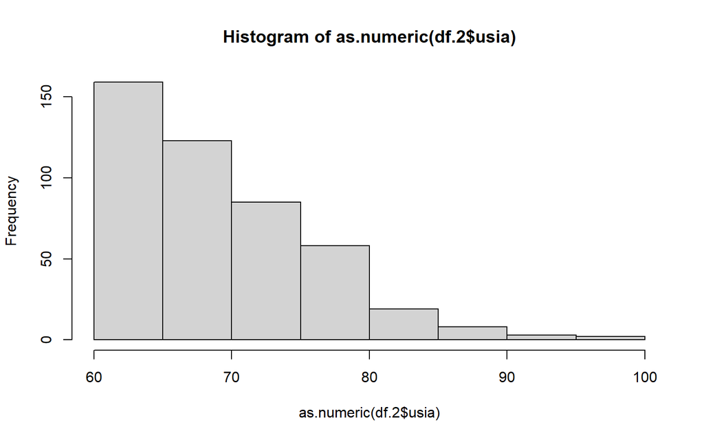

```r
hist(as.numeric(df.2$usia))
```

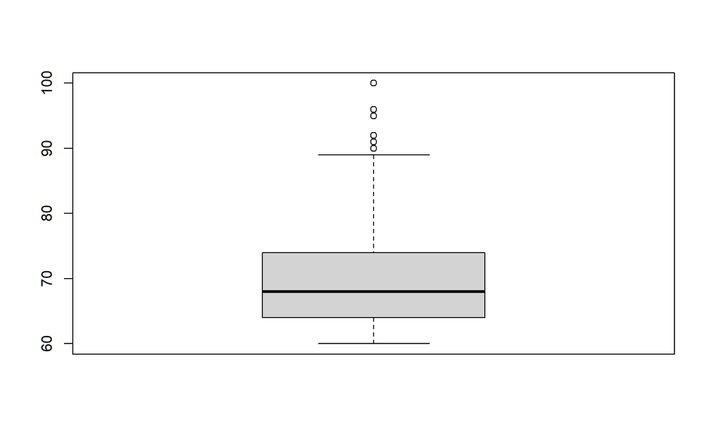

```r
boxplot(df.2$usia)
```

# Status nikah

```r
df.2 %>%
  count(statusnikah)
```

```
##   statusnikah   n
## 1         1.0 291
## 2         2.0 154
## 3         2.7   1
## 4         3.0  11
```

Ada error, status nikah kok 2.7

```r
df.2[which(df.2$statusnikah == 2.7),]
```

```
##     jeniskelamin usia statusnikah pendidikan pekerjaan ruangrwt masukdari
## 366            2   60         2.7          1         4        2         1
##     pembiayaan delirium     tglmask     tgldelir       tglplg lamaperawatan
## 366          3        1 31 mei 2010 11 juni 2010 11 juni 2010            NA
##     kondisiplg timedelirium TIME STATUSDELIRIUM INFEKSIJUGA PENSTATUSFUNGSION
## 366          2           11   11              1           1                 1
##     GGNKOGNITIF KATALBUMIN HIPOKSIA GANGGUANMETABOLIK STROKRIWAYAT ANEMIA
## 366           1          1        0                 1            0      1
##     JENKELBARU KATUMURBARU JUMLAHOBATBARU PENYJANTUNGBARU
## 366          0           0              1               1
```

# Pendidikan

```r
df.2 %>%
  count(pendidikan)
```

```
##   pendidikan   n
## 1          1  32
## 2          2 118
## 3          3  99
## 4          4 138
## 5          5  68
## 6         NA   2
```

# Hubungan usia dengan pendidikan

- gada sih, karena usianya start from 60 and end in 100 ada yang missing value 2

```r
df.2 %>%
  filter(is.na(pendidikan))
```

```
##   jeniskelamin usia statusnikah pendidikan pekerjaan ruangrwt masukdari
## 1            1   60           1         NA         3        2         1
## 2            1   78           1         NA         4        2         1
##   pembiayaan delirium     tglmask    tgldelir      tglplg lamaperawatan
## 1          3        1 20 okt 2009  2 okt 2010 10 okt 2010            NA
## 2          3        1 20 okt 2009 23 okt 2009   10-Nov-09            NA
##   kondisiplg timedelirium TIME STATUSDELIRIUM INFEKSIJUGA PENSTATUSFUNGSION
## 1          1           12   12              1           1                 1
## 2          1            3    3              1           1                 1
##   GGNKOGNITIF KATALBUMIN HIPOKSIA GANGGUANMETABOLIK STROKRIWAYAT ANEMIA
## 1           0          1        1                NA            0      0
## 2           0          1        1                NA            0      0
##   JENKELBARU KATUMURBARU JUMLAHOBATBARU PENYJANTUNGBARU
## 1          1           0              1               1
## 2          1           1              1               2
```

```r
df.2[which(is.na(df.2$pendidikan)),]
```

```
##     jeniskelamin usia statusnikah pendidikan pekerjaan ruangrwt masukdari
## 307            1   60           1         NA         3        2         1
## 315            1   78           1         NA         4        2         1
##     pembiayaan delirium     tglmask    tgldelir      tglplg lamaperawatan
## 307          3        1 20 okt 2009  2 okt 2010 10 okt 2010            NA
## 315          3        1 20 okt 2009 23 okt 2009   10-Nov-09            NA
##     kondisiplg timedelirium TIME STATUSDELIRIUM INFEKSIJUGA PENSTATUSFUNGSION
## 307          1           12   12              1           1                 1
## 315          1            3    3              1           1                 1
##     GGNKOGNITIF KATALBUMIN HIPOKSIA GANGGUANMETABOLIK STROKRIWAYAT ANEMIA
## 307           0          1        1                NA            0      0
## 315           0          1        1                NA            0      0
##     JENKELBARU KATUMURBARU JUMLAHOBATBARU PENYJANTUNGBARU
## 307          1           0              1               1
## 315          1           1              1               2
```

# Pekerjaan

```r
df.2 %>%
  count(pekerjaan)
```

```
##   pekerjaan   n
## 1         1 151
## 2         2 161
## 3         3  67
## 4         4  78
```

# Ruang Rawat

```r
df.2 %>%
  count(ruangrwt)
```

```
##   ruangrwt   n
## 1        1 289
## 2        2  99
## 3        3  33
## 4        4  36
```

# Masuk Dari

```r
df.2 %>%
  count(masukdari)
```

```
##   masukdari   n
## 1         1 365
## 2         2  92
```

# Pembiayaan

```r
df.2 %>%
  mutate(
    pembiayaan = as.factor(pembiayaan)
  ) %>%
  count(pembiayaan)
```

```
##   pembiayaan   n
## 1          1 130
## 2          2 219
## 3          3 108
```

# Delirium

```r
df.2 %>%
  count(delirium)
```

```
##   delirium   n
## 1        0 360
## 2        1  97
```

# Tanggal Masuk

```r
df.2$tglmask
```

```
##   [1] "4-Jan-09"       "4 maret 2009"   "16-Sep-09"      "17 maret 2010"
##   [5] "1-Feb-10"       "10-Nov-10"      "9-Jan-09"       "28-Jan-09"
##   [9] "31 maret 2009"  "25 agt 2010"    "22-Jan-09"      "1-Sep-10"
##  [13] "14-Jan-10"      "13-Sep-10"      "17-Sep-10"      "1-Nov-09"
##  [17] "2-Jan-10"       "8-Feb-10"       "29 okt 2010"    "27-Nov-10"
##  [21] "1-Sep-10"       "7-Apr-09"       "21-Jan-10"      "25 okt 2010"
##  [25] "2-Feb-10"       "16-Apr-09"      "1 okt 2009"     "2 agt 2009"
##  [29] "21 juni 2009"   "6 agt 2009"     "16 juli2009"    "11 agt 2009"
##  [33] "16-Jan-09"      "20 maret 2009"  "24-Nov-08"      "2  juli 2010"
##  [37] "19-Jan-09"      "26 mei 2010"    "13-Apr-10"      "23 juni 2010"
##  [41] "11 juli 2010"   "27 agt 2010"    "5 agt 2010"     "10 agt 2010"
##  [45] "31-Jan-10"      "27 juli 2010"   " 10 april 2010" "3 juli 2010"
##  [49] "23 juli 2010"   "29 juli 2010"   "19 juli 2010"   "28-Apr-10"
##  [53] "3 maret 2010"   "16 maret 2009"  "28-Apr-09"      "3 juli 2009"
##  [57] "28 juli 2009"   "6-Jan-09"       "17-Apr-09"      "12 juli 2009"
```

[output cut: 100 more lines]

Kek orang gila mikir ini weilah, aku kepikirannya masih manual juga

```r
# library(clock)
# date_parse(
#   df.2$tglmask,
#   format = c("%d-%m-%Y", "%d %m %Y" )
# )
```

Kek gini nih

```r
tgl.masuk <- df.2$tglmask %>%
  tolower() %>%
  str_remove_all("-") %>%
  str_remove_all(" ")

tgl.masuk
```

```
##   [1] "4jan09"       "4maret2009"   "16sep09"      "17maret2010"  "1feb10"
##   [6] "10nov10"      "9jan09"       "28jan09"      "31maret2009"  "25agt2010"
##  [11] "22jan09"      "1sep10"       "14jan10"      "13sep10"      "17sep10"
##  [16] "1nov09"       "2jan10"       "8feb10"       "29okt2010"    "27nov10"
##  [21] "1sep10"       "7apr09"       "21jan10"      "25okt2010"    "2feb10"
##  [26] "16apr09"      "1okt2009"     "2agt2009"     "21juni2009"   "6agt2009"
##  [31] "16juli2009"   "11agt2009"    "16jan09"      "20maret2009"  "24nov08"
##  [36] "2juli2010"    "19jan09"      "26mei2010"    "13apr10"      "23juni2010"
##  [41] "11juli2010"   "27agt2010"    "5agt2010"     "10agt2010"    "31jan10"
##  [46] "27juli2010"   "10april2010"  "3juli2010"    "23juli2010"   "29juli2010"
##  [51] "19juli2010"   "28apr10"      "3maret2010"   "16maret2009"  "28apr09"
##  [56] "3juli2009"    "28juli2009"   "6jan09"       "17apr09"      "12juli2009"
##  [61] "11apr09"      "11des2009"    "3sep09"       "29des2009"    "25des2010"
##  [66] "6sep09"       "28okt2010"    "25nov09"      "15feb10"      "19jan10"
##  [71] "3des2009"     "14jan10"      "7okt2010"     "7nov10"       "19sep09"
```

[output cut: 77 more lines]

januari februari maret april mei juni jul agus sep ok nov des

# split date

```r
# tgl.masuk <- as.data.frame(tgl.masuk)

tgl.masuk <- gsub('([0-9])([a-z])','\\1/\\2', tgl.masuk)
tgl.masuk<- gsub('([a-z])([0-9])','\\1/\\2', tgl.masuk)
tgl.masuk <- as.data.frame(tgl.masuk)
tgl.masuk <- tgl.masuk %>%
  mutate(
    d = str_split(tgl.masuk, pattern = "/")
  )
tgl.masuk
```

```
##          tgl.masuk                d
## 1         4/jan/09       4, jan, 09
## 2     4/maret/2009   4, maret, 2009
## 3        16/sep/09      16, sep, 09
## 4    17/maret/2010  17, maret, 2010
## 5         1/feb/10       1, feb, 10
## 6        10/nov/10      10, nov, 10
## 7         9/jan/09       9, jan, 09
## 8        28/jan/09      28, jan, 09
## 9    31/maret/2009  31, maret, 2009
## 10     25/agt/2010    25, agt, 2010
## 11       22/jan/09      22, jan, 09
## 12        1/sep/10       1, sep, 10
## 13       14/jan/10      14, jan, 10
## 14       13/sep/10      13, sep, 10
```

[output cut: 443 more lines]

```r
tgl <- data.frame(matrix(unlist(tgl.masuk$d), ncol= 3, byrow = TRUE))
length(unique(tgl$X2))
```

```
## [1] 22
```

```r
tgl
```

```
##     X1      X2   X3
## 1    4     jan   09
## 2    4   maret 2009
## 3   16     sep   09
## 4   17   maret 2010
## 5    1     feb   10
## 6   10     nov   10
## 7    9     jan   09
## 8   28     jan   09
## 9   31   maret 2009
## 10  25     agt 2010
## 11  22     jan   09
## 12   1     sep   10
## 13  14     jan   10
## 14  13     sep   10
```

[output cut: 443 more lines]

Gabungin tgl.masuk dengan tgl

```r
tgl.masuk <- data.frame(
  tgl.masuk, tgl
)

tgl.masuk[144,]
```

```
##      tgl.masuk            d X1 X2   X3
## 144 90/kt/2008 90, kt, 2008 90 kt 2008
```

```r
length(unique(tgl.masuk$X1))
```

```
## [1] 32
```

```r
unique(tgl.masuk$X1)
```

```
##  [1] "4"  "16" "17" "1"  "10" "9"  "28" "31" "25" "22" "14" "13" "2"  "8"  "29"
## [16] "27" "7"  "21" "6"  "11" "20" "24" "19" "26" "23" "5"  "3"  "12" "15" "18"
## [31] "30" "90"
```

Ini di tanggal ada yang tanggal 90 T_T

```r
# Melihat mana sih yang ga jelas kok ada tanggal 90
subset(df.2, grepl('^9', df.2$tglmask))
```

```
##     jeniskelamin usia statusnikah pendidikan pekerjaan ruangrwt masukdari
## 7              2   65           1          2         1        1         1
## 85             2   62           1          5         2        1         1
## 132            1   82           2          2         4        1         1
## 133            1   60           1          4         2        1         1
## 144            2   64           1          2         1        1         1
## 168            2   76           2          5         2        1         1
## 231            1   67           1          5         2        1         1
## 236            1   80           1          2         1        1         1
## 250            1   74           3          2         4        1         2
## 290            2   66           3          1         1        1         1
## 308            1   76           1          5         4        2         1
## 456            1   62           1          4         3        2         2
##     pembiayaan delirium     tglmask     tgldelir       tglplg lamaperawatan
## 7            1        1    9-Jan-09    12-Jan-09    17-Jan-09            NA
```

[output cut: 50 more lines]

Problem solved, karena row 144 pas nulis tanggal masuk itu jadi bulannya diawali dengan angka (“0kt”)

```r
tgl.masuk <- tgl.masuk %>%
  mutate(
    X1 = ifelse(X1 == "90", "9", X1)
  )

tgl.masuk %>%
  select(X1) %>%
  arrange(as.numeric(X1)) %>%
  unique()
```

```
##     X1
## 1    1
## 17   2
## 29   3
## 48   4
## 63   5
## 74   6
## 88   7
## 102  8
## 118  9
## 130 10
## 148 11
## 164 12
## 179 13
## 194 14
```

[output cut: 17 more lines]

```r
# alhamdulillah tanggalnya gada yang aneh aneh lagi
```

# Perbaiki bulannya

```r
length(unique(tgl.masuk$X2))
```

```
## [1] 22
```

```r
unique(tgl.masuk$X2)
```

```
##  [1] "jan"     "maret"   "sep"     "feb"     "nov"     "agt"     "okt"
##  [8] "apr"     "juni"    "juli"    "mei"     "april"   "des"     "kt"
## [15] "jsn"     "de"      "mart"    "spt"     "jun"     "junii"   "januari"
## [22] "fen"
```

!!!!!!!!!!!!!!!!!!!!!!!!!!!!!!!!!!!!!!!!!!!!!!!!!!!!!!!!!!!!!!!!!!!!!!!!!!!!!!!!!!!!!!!!!!!!!!!!!!!!!!!!!!!!!!!!!!!!!!!!!!!!!!!!!!!!!!!!!!!!!!

!!!!!!!!!!!!!!!!!!!!!!!!!!!!!!!!!!!!!!!!!!!!!!!!!!!!!!!!!!!!!!!!!!!!!!!!!!!!!!!!!!!!!!!!!!!!!!!!!!!!!!!!!!!!!!!!!!!!!!!!!!!!!!!!!!!!!!!!!!!!!!

Mari Kita benerin bulannya

```r
# tgl.masuk <- tgl.masuk %>%
#   mutate(
#     X2 = case_when(
#       starts_with("jan") ~ "Januari"
#
#     #
  # )
```

```r
tgl.masuk <- tgl.masuk %>%
  # select(X2) %>%
  mutate(
    X2 = case_when(
      grepl('^ja', X2) ~ "Januari",
      grepl('^fe', X2) ~ "Februari",
      grepl('^ma', X2) ~ "Maret",
      grepl('^ap', X2) ~ "April",
      grepl('^me', X2) ~ "Mei",
      grepl('^jun', X2) ~ "Juni",
      grepl('^jul', X2) ~ "Juli",
      grepl('^ag', X2) ~ "Agustus",
      grepl('^s', X2) ~ "September",
      grepl('^ok', X2) ~ "Oktober",
      grepl('^nov', X2) ~ "November",
      grepl('^de', X2) ~ "Desember",
      grepl('^kt', X2) ~ "Oktober", # dia membenarkan yang typo oktober dengan awalan 0
      grepl('^js', X2) ~ "Oktober" # ini typo parah
      )
    )
tgl.masuk
```

```
##          tgl.masuk                d X1        X2   X3
## 1         4/jan/09       4, jan, 09  4   Januari   09
## 2     4/maret/2009   4, maret, 2009  4     Maret 2009
## 3        16/sep/09      16, sep, 09 16 September   09
## 4    17/maret/2010  17, maret, 2010 17     Maret 2010
## 5         1/feb/10       1, feb, 10  1  Februari   10
## 6        10/nov/10      10, nov, 10 10  November   10
## 7         9/jan/09       9, jan, 09  9   Januari   09
## 8        28/jan/09      28, jan, 09 28   Januari   09
## 9    31/maret/2009  31, maret, 2009 31     Maret 2009
## 10     25/agt/2010    25, agt, 2010 25   Agustus 2010
## 11       22/jan/09      22, jan, 09 22   Januari   09
## 12        1/sep/10       1, sep, 10  1 September   10
## 13       14/jan/10      14, jan, 10 14   Januari   10
## 14       13/sep/10      13, sep, 10 13 September   10
```

[output cut: 443 more lines]

```r
tgl.masuk %>%
  count(X2)
```

```
##           X2  n
## 1    Agustus 42
## 2      April 40
## 3   Desember 28
## 4   Februari 33
## 5    Januari 38
## 6       Juli 34
## 7       Juni 36
## 8      Maret 49
## 9        Mei 37
## 10  November 44
## 11   Oktober 40
## 12 September 36
```

```r
length(unique(tgl.masuk$X3))
```

```
## [1] 12
```

```r
unique(tgl.masuk$X3)
```

```
##  [1] "09"   "2009" "2010" "10"   "08"   "11"   "2011" "2008" "1010" "2006"
## [11] "201"  "2020"
```

```r
tgl.masuk %>%
  mutate(
    X3 = case_when( # menghindari perbedaan format, tapi tang 3 huruf ini gatau nanti isinya apa
      nchar(X3) == 2 ~ paste0("20", X3),
      nchar(X3) == 3 ~ paste(X3),
      nchar(X3) == 4 ~ paste(X3)
    ),
    X3 = case_when(
      grepl('^1', X3) ~ paste("2010"),
      TRUE ~ as.character(X3)

    )

  ) %>%
  count(X3)
```

```
##     X3   n
## 1 2006   1
## 2 2008 118
## 3 2009 187
## 4  201   1
## 5 2010 147
## 6 2011   2
## 7 2020   1
```

Nanti yang 201 bisa diperbaikin ketika ngelihat tgl keluarnya sama tgl deliriumnya

```r
df.2[grep("201$", df.2$tglmask), ]
```

```
##     jeniskelamin usia statusnikah pendidikan pekerjaan ruangrwt masukdari
## 438            2   72           2          4         1        2         1
##     pembiayaan delirium        tglmask tgldelir    tglplg lamaperawatan
## 438          3        0 29 januari 201          19-Feb-10            22
##     kondisiplg timedelirium TIME STATUSDELIRIUM INFEKSIJUGA PENSTATUSFUNGSION
## 438          1           NA   14              0           1                 0
##     GGNKOGNITIF KATALBUMIN HIPOKSIA GANGGUANMETABOLIK STROKRIWAYAT ANEMIA
## 438           0          0        0                 0            0      0
##     JENKELBARU KATUMURBARU JUMLAHOBATBARU PENYJANTUNGBARU
## 438          0           1              1               1
```

Dia ini memang error ygy

```r
tgl.masuk <- tgl.masuk %>%
  mutate(
    X3 = case_when( # menghindari perbedaan format, tapi tang 3 huruf ini gatau nanti isinya apa
      nchar(X3) == 2 ~ paste0("20", X3),
      nchar(X3) == 3 ~ paste(X3),
      nchar(X3) == 4 ~ paste(X3)
    ),
    X3 = case_when(
      grepl('^1', X3) ~ paste("2010"),
      TRUE ~ as.character(X3)

    )

  )
tgl.masuk
```

```
##          tgl.masuk                d X1        X2   X3
## 1         4/jan/09       4, jan, 09  4   Januari 2009
## 2     4/maret/2009   4, maret, 2009  4     Maret 2009
## 3        16/sep/09      16, sep, 09 16 September 2009
## 4    17/maret/2010  17, maret, 2010 17     Maret 2010
## 5         1/feb/10       1, feb, 10  1  Februari 2010
## 6        10/nov/10      10, nov, 10 10  November 2010
## 7         9/jan/09       9, jan, 09  9   Januari 2009
## 8        28/jan/09      28, jan, 09 28   Januari 2009
## 9    31/maret/2009  31, maret, 2009 31     Maret 2009
## 10     25/agt/2010    25, agt, 2010 25   Agustus 2010
## 11       22/jan/09      22, jan, 09 22   Januari 2009
## 12        1/sep/10       1, sep, 10  1 September 2010
## 13       14/jan/10      14, jan, 10 14   Januari 2010
## 14       13/sep/10      13, sep, 10 13 September 2010
```

[output cut: 443 more lines]

# Cek keseuaian bulan dan tahunnya

```r
tgl.masuk <- tgl.masuk %>%
  mutate (
    masuk.fix = paste(X1,X2,X3),

  )
tgl.masuk
```

```
##          tgl.masuk                d X1        X2   X3         masuk.fix
## 1         4/jan/09       4, jan, 09  4   Januari 2009    4 Januari 2009
## 2     4/maret/2009   4, maret, 2009  4     Maret 2009      4 Maret 2009
## 3        16/sep/09      16, sep, 09 16 September 2009 16 September 2009
## 4    17/maret/2010  17, maret, 2010 17     Maret 2010     17 Maret 2010
## 5         1/feb/10       1, feb, 10  1  Februari 2010   1 Februari 2010
## 6        10/nov/10      10, nov, 10 10  November 2010  10 November 2010
## 7         9/jan/09       9, jan, 09  9   Januari 2009    9 Januari 2009
## 8        28/jan/09      28, jan, 09 28   Januari 2009   28 Januari 2009
## 9    31/maret/2009  31, maret, 2009 31     Maret 2009     31 Maret 2009
## 10     25/agt/2010    25, agt, 2010 25   Agustus 2010   25 Agustus 2010
## 11       22/jan/09      22, jan, 09 22   Januari 2009   22 Januari 2009
## 12        1/sep/10       1, sep, 10  1 September 2010  1 September 2010
## 13       14/jan/10      14, jan, 10 14   Januari 2010   14 Januari 2010
## 14       13/sep/10      13, sep, 10 13 September 2010 13 September 2010
```

[output cut: 443 more lines]

```r
length(unique(tgl.masuk$masuk.fix))
```

```
## [1] 363
```

```r
unique(tgl.masuk$masuk.fix)
```

```
##   [1] "4 Januari 2009"    "4 Maret 2009"      "16 September 2009"
##   [4] "17 Maret 2010"     "1 Februari 2010"   "10 November 2010"
##   [7] "9 Januari 2009"    "28 Januari 2009"   "31 Maret 2009"
##  [10] "25 Agustus 2010"   "22 Januari 2009"   "1 September 2010"
##  [13] "14 Januari 2010"   "13 September 2010" "17 September 2010"
##  [16] "1 November 2009"   "2 Januari 2010"    "8 Februari 2010"
##  [19] "29 Oktober 2010"   "27 November 2010"  "7 April 2009"
##  [22] "21 Januari 2010"   "25 Oktober 2010"   "2 Februari 2010"
##  [25] "16 April 2009"     "1 Oktober 2009"    "2 Agustus 2009"
##  [28] "21 Juni 2009"      "6 Agustus 2009"    "16 Juli 2009"
##  [31] "11 Agustus 2009"   "16 Januari 2009"   "20 Maret 2009"
##  [34] "24 November 2008"  "2 Juli 2010"       "19 Januari 2009"
##  [37] "26 Mei 2010"       "13 April 2010"     "23 Juni 2010"
##  [40] "11 Juli 2010"      "27 Agustus 2010"   "5 Agustus 2010"
##  [43] "10 Agustus 2010"   "31 Januari 2010"   "27 Juli 2010"
```

[output cut: 106 more lines]

```r
tgl.masuk %>%
  count(masuk.fix)
```

```
##             masuk.fix n
## 1      1 Agustus 2008 1
## 2      1 Agustus 2010 1
## 3     1 Februari 2009 1
## 4     1 Februari 2010 1
## 5      1 Januari 2009 1
## 6         1 Juli 2009 1
## 7         1 Juni 2008 1
## 8        1 Maret 2009 3
## 9     1 November 2009 2
## 10     1 Oktober 2009 2
## 11   1 September 2010 2
## 12    10 Agustus 2010 1
## 13      10 April 2010 1
## 14   10 Desember 2008 1
```

[output cut: 349 more lines]

```r
tgl.masuk <- tgl.masuk %>%
  mutate(
    X2.2 = case_when(
      X2 == "Januari" ~ "01",
      X2 == "Februari" ~ "02",
      X2 == "Maret" ~ "03",
      X2 == "April" ~ "04",
      X2 == "Mei" ~ "05",
      X2 == "Juni" ~ "06",
      X2 == "Juli" ~ "07",
      X2 == "Agustus" ~ "08",
      X2 == "September" ~ "09",
      X2 == "Oktober" ~ "10",
      X2 == "November" ~ "11",
      X2 == "Desember" ~ "12",
    )
  )
```

# Cek apakah aad yang aneh dalam penanggalan

misal, 31 Feb gitu

```r
tgl.masuk <- tgl.masuk %>%
  mutate(
    X1 = as.numeric(X1),
    X3 = as.numeric(X3),
    is.tgl.masuk.error = ifelse(
      (
        ((between(X1, 1,31) & (X2 == "Januari"))) |
        ((between(X1 ,1,31) & (X2 == "Maret")))   |
        ((between(X1, 1,31) & (X2 == "Mei")))     |
        ((between(X1, 1,31) & (X2 == "Juli")))    |
        ((between(X1, 1,31) & (X2 == "Agustus"))) |
        ((between(X1, 1,31) & (X2 == "Oktober"))) |
        ((between(X1, 1,31) & (X2 == "Desember")))|
        ((between(X1, 1,30) & (X2 == "April"))) |
        ((between(X1, 1,30) & (X2 == "Juni")))  |
        ((between(X1, 1,30) & (X2 == "September"))) |
        ((between(X1, 1,30) & (X2 == "November")))  |
        ((between(X1, 1,28) & (X2 == "Februari")) & (X3 %% 4 != 0)) |
        ((between(X1, 1,29) & (X2 == "Februari")) & (X3 %% 4 == 0))
      ) & (between(X3,2000,2020)),
    0, # if date is no error
    1) # if date is error
  )
tgl.masuk %>%
  count(is.tgl.masuk.error)
```

```
##   is.tgl.masuk.error   n
## 1                  0 456
## 2                  1   1
```

# Tgl Keluar

```r
df.2$tglplg
```

```
##   [1] "9-Jan-09"       " 11 maret 2009" "29-Sep-09"      "9-Apr-10"
##   [5] "5-Feb-10"       "19-Nov-11"      "17-Jan-09"      "1 maret 2009"
##   [9] "2-Apr-09"       "6-Sep-10"       "6-Feb-09"       "8-Sep-10"
##  [13] "5-Feb-10"       "19-Sep-10"      "30-Sep-10"      "10-Nov-09"
##  [17] "7-Jan-10"       "16-Feb-10"      "17-Nov-10"      "29-Nov-10"
##  [21] " 18 sep 2010"   "14-Apr-09"      "24-Jan-10"      "12-Nov-10"
##  [25] "17-Feb-10"      "23-Apr-09"      "3-Nov-09"       "10 agt 2009"
##  [29] "24 juni 2009"   "12 agt 2009"    "27 juli 2009"   "14 agt 2009"
##  [33] "25-Jan-09"      " 21 maret 2009" "28-Nov-09"      "15 juli 2010"
##  [37] "21-Jan-09"      "2 juni 2010"    "19-Apr-10"      "26 juni 2010"
##  [41] "16 juli 2010"   "3-Sep-10"       "17 agt 2010"    "12 agt 2010"
##  [45] "21-Feb-11"      "22 agt 2010"    "20-Apr-10"      "16 juli 2010"
##  [49] "13 agt 2010"    "11 agt 2010"    "27 juli 2010"   "10 mei 2010"
##  [53] "28 maret 2010"  "23 maret 2009"  "12 mei 2009"    "7 juli 2009"
##  [57] "31 juli 2009"   "8-Jan-09"       "20-Apr-09"      "14 juli 2009"
```

[output cut: 100 more lines]

```r
tgl.pulang <- df.2$tglplg %>%
  tolower() %>%
  str_remove_all("-") %>%
  str_remove_all(" ")

tgl.pulang
```

```
##   [1] "9jan09"       "11maret2009"  "29sep09"      "9apr10"       "5feb10"
##   [6] "19nov11"      "17jan09"      "1maret2009"   "2apr09"       "6sep10"
##  [11] "6feb09"       "8sep10"       "5feb10"       "19sep10"      "30sep10"
##  [16] "10nov09"      "7jan10"       "16feb10"      "17nov10"      "29nov10"
##  [21] "18sep2010"    "14apr09"      "24jan10"      "12nov10"      "17feb10"
##  [26] "23apr09"      "3nov09"       "10agt2009"    "24juni2009"   "12agt2009"
##  [31] "27juli2009"   "14agt2009"    "25jan09"      "21maret2009"  "28nov09"
##  [36] "15juli2010"   "21jan09"      "2juni2010"    "19apr10"      "26juni2010"
##  [41] "16juli2010"   "3sep10"       "17agt2010"    "12agt2010"    "21feb11"
##  [46] "22agt2010"    "20apr10"      "16juli2010"   "13agt2010"    "11agt2010"
##  [51] "27juli2010"   "10mei2010"    "28maret2010"  "23maret2009"  "12mei2009"
##  [56] "7juli2009"    "31juli2009"   "8jan09"       "20apr09"      "14juli2009"
##  [61] "26apr09"      "23des2009"    "10sep09"      "30des2009"    "31des2010"
##  [66] "15sep09"      "2nov10"       "1des2009"     "24feb10"      "4feb10"
##  [71] "23des2009"    "18jan10"      "18okt2010"    "19nov2010"    "25nov09"
```

[output cut: 77 more lines]

```r
tgl.pulang <- gsub('([0-9])([a-z])','\\1/\\2', tgl.pulang)
tgl.pulang <- gsub('([a-z])([0-9])','\\1/\\2', tgl.pulang)
tgl.pulang <- as.data.frame(tgl.pulang)
tgl.pulang <- tgl.pulang %>%
  mutate(
    d = str_split(tgl.pulang, pattern = "/")
  )
tgl.pulang
```

```
##         tgl.pulang                d
## 1         9/jan/09       9, jan, 09
## 2    11/maret/2009  11, maret, 2009
## 3        29/sep/09      29, sep, 09
## 4         9/apr/10       9, apr, 10
## 5         5/feb/10       5, feb, 10
## 6        19/nov/11      19, nov, 11
## 7        17/jan/09      17, jan, 09
## 8     1/maret/2009   1, maret, 2009
## 9         2/apr/09       2, apr, 09
## 10        6/sep/10       6, sep, 10
## 11        6/feb/09       6, feb, 09
## 12        8/sep/10       8, sep, 10
## 13        5/feb/10       5, feb, 10
## 14       19/sep/10      19, sep, 10
```

[output cut: 443 more lines]

```r
tgl.2 <- data.frame(matrix(unlist(tgl.pulang$d), ncol= 3, byrow = TRUE))
length(unique(tgl.2$X2))
```

```
## [1] 48
```

```r
tgl.2
```

```
##           X1     X2     X3
## 1          9    jan     09
## 2         11  maret   2009
## 3         29    sep     09
## 4          9    apr     10
## 5          5    feb     10
## 6         19    nov     11
## 7         17    jan     09
## 8          1  maret   2009
## 9          2    apr     09
## 10         6    sep     10
## 11         6    feb     09
## 12         8    sep     10
## 13         5    feb     10
## 14        19    sep     10
```

[output cut: 443 more lines]

# Tgl Delir

```r
df.2$tgldelir
```

```
##   [1] " "             " "             " "             " "
##   [5] " "             " "             "12-Jan-09"     " "
##   [9] " "             " "             " "             "-"
##  [13] "4-Feb-10"      "18-Sep-10"     "19-Sep-10"     "-"
##  [17] "-"             "9-Feb-10"      "-"             "-"
##  [21] "15-Sep-10"     " "             " "             " "
##  [25] " "             " "             " "             " "
##  [29] " "             " "             " "             " "
##  [33] " "             " "             " "             " "
##  [37] " "             " "             "18-Apr-10"     " "
##  [41] " "             " "             " "             " "
##  [45] " "             " "             " "             " "
##  [49] "12 agt 2010"   " "             "21 juli 2010"  " "
##  [53] "5 maret 2010"  " "             " "             " "
##  [57] " "             " "             "19-Apr-09"     " "
```

[output cut: 100 more lines]

Inkonsisensi dalam penulisannya delir

# Hubungan Tgl Delir dengan Delir

```r
df.2 %>%
  select(delirium, tgldelir)
```

```
##     delirium      tgldelir
## 1          0
## 2          0
## 3          0
## 4          0
## 5          0
## 6          0
## 7          1     12-Jan-09
## 8          0
## 9          0
## 10         0
## 11         0
## 12         0             -
## 13         1      4-Feb-10
## 14         1     18-Sep-10
```

[output cut: 443 more lines]

## Hubungan delir = 1 dengan tgl ditetapkannya delirium

```r
df.2 %>%
  select(delirium, tgldelir) %>%
  filter(delirium == 1)
```

```
##    delirium      tgldelir
## 1         1     12-Jan-09
## 2         1      4-Feb-10
## 3         1     18-Sep-10
## 4         1     19-Sep-10
## 5         1      9-Feb-10
## 6         1     15-Sep-10
## 7         1     18-Apr-10
## 8         1   12 agt 2010
## 9         1  21 juli 2010
## 10        1  5 maret 2010
## 11        1     19-Apr-09
## 12        1   14 des 2009
## 13        1      9-Sep-09
## 14        1     17-Feb-10
```

[output cut: 83 more lines]

Tidak ada masalah, artinya semua yang diputuskan sebagai delirium itu udah ada data tanggalnya

```r
df.2 %>%
  select(delirium, tgldelir) %>%
  filter(delirium == 0) %>%
  count(delirium,tgldelir)
```

```
##   delirium tgldelir   n
## 1        0        -   5
## 2        0          355
```

Sama seperti di atas, tidak ada masalah dari delirium yang belum ditetapkan karena tidak ada tanggalnya

# Variabel Lama Perawatan

```r
df.2 %>%
  select(lamaperawatan) %>%
  count(lamaperawatan)
```

```
##    lamaperawatan  n
## 1              0  2
## 2              1 11
## 3              2 15
## 4              3 24
## 5              4 27
## 6              5 26
## 7              6 31
## 8              7 35
## 9              8 24
## 10             9 18
## 11            10 21
## 12            11 12
## 13            12 15
## 14            13  9
```

[output cut: 23 more lines]

terdapat 97 missing value, tidak ada informasi lanjutan apakah ini hari atau jam atau apa, tapi ini masih makesense dalam lama perawatan (waktu)

# Kondisi Pulang

```r
df.2 %>%
  count(kondisiplg)
```

```
##   kondisiplg   n
## 1          1 330
## 2          2  57
## 3          3  70
```

Stabil, gada masalah

# Time Derilium

```r
df.2 %>%
  count(timedelirium)
```

```
##    timedelirium   n
## 1             1  11
## 2             2  26
## 3             3  14
## 4             4   6
## 5             5   7
## 6             6   4
## 7             7   2
## 8             8   4
## 9             9   3
## 10           10   5
## 11           11   1
## 12           12   3
## 13           15   2
## 14           16   1
## 15           17   2
## 16           20   1
## 17           23   1
## 18           24   1
## 19           27   1
## 20           28   1
## 21           36   1
## 22           NA 360
```

terdapat sejumlah 360 missing value

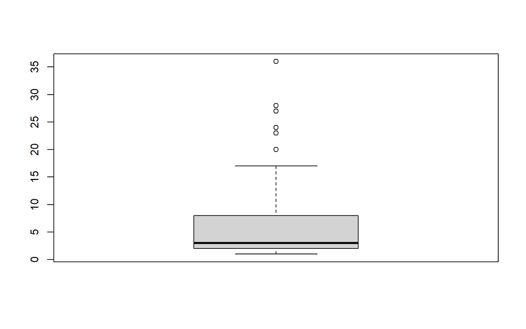

```r
boxplot(df.2$timedelirium)
```

terdapat maslah outlier extreme

# TIME

tidak ada penjelasan lebih lanjut mengenai apa itu “time”, sehingga tidak bisa dilihat korelasi dengan variabel maupun keadaan riil nya tetapi tidak ada masalah missing value

```r
df.2 %>%
  count(TIME)
```

```
##    TIME   n
## 1     0   2
## 2     1  23
## 3     2  41
## 4     3  38
## 5     4  33
## 6     5  33
## 7     6  35
## 8     7  37
## 9     8  28
## 10    9  20
## 11   10  27
## 12   11  12
## 13   12  18
## 14   13   9
## 15   14 101
```

# STATUSDELIRIUM

```r
df.2 %>%
  count(STATUSDELIRIUM)
```

```
##   STATUSDELIRIUM   n
## 1              0 371
## 2              1  86
```

## Korelasi Status dengan delirium

```r
df.2 %>%
  select(delirium, STATUSDELIRIUM) %>%
  count(delirium, STATUSDELIRIUM)
```

```
##   delirium STATUSDELIRIUM   n
## 1        0              0 360
## 2        1              0  11
## 3        1              1  86
```

ini cukup mencurigakan, tetapi ga bisa diambil kesimpulan karena kurang tahu mengenai metadata dari delirium dan status delirium itu sendiri ada 11 record yang tidak konsisten

# INFEKSIJUGA

```r
df.2 %>%
  count(INFEKSIJUGA)
```

```
##   INFEKSIJUGA   n
## 1           0 110
## 2           1 269
## 3           2  78
```

# PENSTATUSFUNGSION

missing value

```r
df.2 %>%
  count(PENSTATUSFUNGSION)
```

```
##   PENSTATUSFUNGSION   n
## 1                 0 325
## 2                 1 106
## 3                NA  26
```

# GGNKOGNITIF

missing value

```r
df.2 %>%
  count(GGNKOGNITIF)
```

```
##   GGNKOGNITIF   n
## 1           0 335
## 2           1  85
## 3          NA  37
```

# KATALBUMIN

missingvalue

```r
df.2 %>%
  count(KATALBUMIN)
```

```
##   KATALBUMIN   n
## 1          0 224
## 2          1 181
## 3         NA  52
```

# HIPOKSIA

missing value

```r
df.2 %>%
  count(HIPOKSIA)
```

```
##   HIPOKSIA   n
## 1        0 271
## 2        1  85
## 3       NA 101
```

# GANGGUANMETABOLIK

missing value

```r
df.2 %>%
  count(GANGGUANMETABOLIK)
```

```
##   GANGGUANMETABOLIK   n
## 1                 0 240
## 2                 1 166
## 3                NA  51
```

# STROKRIWAYAT

```r
df.2 %>%
  count(STROKRIWAYAT)
```

```
##   STROKRIWAYAT   n
## 1            0 400
## 2            1  57
```

# ANEMIA

```r
df.2 %>%
  count(ANEMIA)
```

```
##   ANEMIA   n
## 1      0 289
## 2      1 168
```

# JENKELBARU

```r
df.2 %>%
  count(JENKELBARU)
```

```
##   JENKELBARU   n
## 1          0 217
## 2          1 240
```

# KATUMURBARU

```r
df.2 %>%
  count(KATUMURBARU)
```

```
##   KATUMURBARU   n
## 1           0 255
## 2           1 156
## 3           2  46
```

# JUMLAHOBATBARU

```r
df.2 %>%
  count(JUMLAHOBATBARU)
```

```
##   JUMLAHOBATBARU   n
## 1              0 212
## 2              1 202
## 3              2  43
```

# PENYJANTUNGBARU

```r
df.2 %>%
  count(PENYJANTUNGBARU)
```

```
##   PENYJANTUNGBARU   n
## 1               0 274
## 2               1 114
## 3               2  69
```

```r
df.2$dup <-  duplicated(df.2)
df.2 %>%
  filter(dup == TRUE)
```

```
##   jeniskelamin usia statusnikah pendidikan pekerjaan ruangrwt masukdari
## 1            2   71           2          1         1        1         1
## 2            2   65           1          4         2        1         1
## 3            1   60           1          5         3        1         1
##   pembiayaan delirium       tglmask tgldelir        tglplg lamaperawatan
## 1          1        0  1 maret 2009           5 maret 2009             4
## 2          2        0 10 maret 2009          16 maret 2009             6
## 3          1        0     11-Apr-09             1 mei 2009            20
##   kondisiplg timedelirium TIME STATUSDELIRIUM INFEKSIJUGA PENSTATUSFUNGSION
## 1          1           NA    4              0           1                 0
## 2          1           NA    6              0           1                 0
## 3          1           NA   14              0           1                 1
##   GGNKOGNITIF KATALBUMIN HIPOKSIA GANGGUANMETABOLIK STROKRIWAYAT ANEMIA
## 1           1          1        0                 1            0      1
## 2           0          1        0                 1            0      1
## 3          NA          0        0                 0            0      0
##   JENKELBARU KATUMURBARU JUMLAHOBATBARU PENYJANTUNGBARU  dup
## 1          0           1              1               1 TRUE
## 2          0           0              0               0 TRUE
## 3          1           0              1               2 TRUE
```

# Pemberian Tanda pada record yang terdapat anomali

```r
df.3 <- df.2 %>%
  mutate(
    # Menandai yang terdapat duplikasi data
    flank_duplicate =
      case_when(
        dup == TRUE ~ 1,
        dup != TRUE ~ 0
      ),

    # Menandai status nikah yang noisy
    flank_status_nikah =
      case_when(
        ((statusnikah == 1) | (statusnikah == 2) |(statusnikah == 3)) ~ 0,
        !((statusnikah == 1) | (statusnikah == 2) |(statusnikah == 3)) ~ 1,
      ),

    # Menandai data Missing pendidikan
    flank_NA_pendidikan =
      case_when(
        is.na(pendidikan) ~ 1,
        !(is.na(pendidikan)) ~ 0
      ),

    # Menandai NA "lama perawatan"
    flank_NA_perawatan =
      case_when(
        is.na(lamaperawatan) ~ 1,
        !(is.na(lamaperawatan)) ~ 0
      ),

    # Menandai NA "time delirium"
    flank_NA_time_delir =
      case_when(
        is.na(timedelirium) ~ 1,
        !(is.na(timedelirium)) ~ 0
      ),

    # Menandai NA "PENSTATUSFUNGSION"
    flank_NA_PENSTATUSFUNGSION =
      case_when(
        is.na(PENSTATUSFUNGSION) ~ 1,
        !(is.na(PENSTATUSFUNGSION)) ~ 0
      ),

    # Menandai NA "GGNKOGNITIF"
    flank_NA_GGNKOGNITIF =
      case_when(
        is.na(GGNKOGNITIF) ~ 1,
        !(is.na(GGNKOGNITIF)) ~ 0
      ),

    # Menandai NA "KATALBUMIN"
    flank_NA_KATALBUMIN =
      case_when(
        is.na(KATALBUMIN) ~ 1,
        !(is.na(KATALBUMIN)) ~ 0
      ),

    # Menandai NA "HIPOKSIA"
    flank_NA_HIPOKSIA =
      case_when(
        is.na(HIPOKSIA) ~ 1,
        !(is.na(HIPOKSIA)) ~ 0
      ),


    # Menandai NA "GANGGUANMETABOLIK"
    flank_NA_GANGGUANMETABOLIK =
      case_when(
        is.na(GANGGUANMETABOLIK) ~ 1,
        !(is.na(GANGGUANMETABOLIK)) ~ 0
      ),

    # Menandai minimal ada 1 variabel yang NA dalam suatu record tsb

    flank_NA_total =
      case_when(
        (
          (flank_NA_pendidikan == 1) |
          (flank_NA_perawatan == 1) |
          (flank_NA_time_delir == 1) |
          (flank_NA_PENSTATUSFUNGSION == 1) |
          (flank_NA_GGNKOGNITIF == 1) |
          (flank_NA_KATALBUMIN == 1) |
          (flank_NA_HIPOKSIA == 1) |
          (flank_NA_GANGGUANMETABOLIK == 1)
        ) ~ 1,
        TRUE ~ 0
      ),
    # Keseluruhan mengandung minimal ada 1 nilai NA, hal ini memang bentuk datanya adalah seperti itu


    # Mengecek apakah terjadi konsistensi antara variabel delirium dengan Status Delirium
    is.same.1 =
      STATUSDELIRIUM == delirium,

    # Transformasi Z untuk melihat apakah terdapat outlier atau tidak

    z.usia = scale(usia),
    z.lamaperawatan = scale(lamaperawatan),
    z.TIME = scale(TIME),

    # Cek Outlier yang mana jika nilai |z| > 2.5
    outlier.usia =
      case_when(
        abs(z.usia) >= 2.5 ~ 1,
        TRUE ~ 0
      ),
    outlier.lamaperawatan =
      case_when(
        abs(z.lamaperawatan) >= 2.5 ~ 1,
        TRUE ~ 0
      ),
    outlier.TIME =
      case_when(
        abs(z.TIME) >= 2.5 ~ 1,
        TRUE ~ 0
      )
  )
```

Catatan : - “Jenis kelamin” udah lengkap dan udah bener, laki dan perempuan - “Usia” seharusnya gada yang aneh, udah make sense, dari 60 - 100, kalau mau lihat usia persebaran usianya ada di bawah - “Status Nikah” Ada yang error (noisy), status nikah 2.7 –> record ke 366 - “Pendidikan”, ada yang NA (2) –> record ke 307 da 315 - “Pekerjaan”, aman - “Ruang Rawat”, aman - “Masuk Dari, aman -”Pembiayaan”, aman harusnya - “delirium”, aman harusny a - “tgl.mask”, –> BANYAK ERRORNYA HHHHH . inkonsistensi format tanggalnya. inkonsistensi dalam format –> ada yang double spasi . typo –> “okt” jadi “0kt” –> menyebabkan salah dalam pas mau di split (row 144) . typo nulias tahun, contoh : 1010 dan 201 - “tgl.keluar” –> Masalahnya kurang lebih sama kaya di tanggal masuk, inkonsistensi yang sangat beragam - “tglderilium” –> kurang lebih bermasalah di inkonsistensi penulisan, untuk hubungan dengan variabel derilium tetap aman - “lamaperawatan” –> terdapat 97 missing value - “kondisiplg” –> gada masalah yang berarti (gada missinig value, gada nilai yang aneh) - “time derililum” –> ada masalah missing value - “TIME”, aman - “STATUSDELIRIUM”, aman –> tetapi ada indikasi tidak konsisten dengan variabel “delirium” tapi tidak bisa diputuskan karena kurangnya informasi - “INFEKSIJUGA”, aman - “PENSTATUSFUNGSION” –> missing value - “GGNKOGNITIF” –> missing value - “KATALBUMIN” –> missing value - “HIPOKSIA” –> missing value - “GANGGUANMETABOLIK” –> missing value - “STROKRIWAYAT”, aman - “ANEMIA”, aman - “JENKELBARU”, aman - “KATUMURBARU”, aman - “JUMLAHOBATBARU”, aman - “PENYJANTUNGBARU”,

```r
df.3
```

```
##     jeniskelamin usia statusnikah pendidikan pekerjaan ruangrwt masukdari
## 1              2   68         1.0          3         1        3         1
## 2              2   64         1.0          4         2        1         1
## 3              2   61         2.0          3         1        3         1
## 4              1   64         1.0          5         2        1         1
## 5              2   63         1.0          4         1        1         2
## 6              2   74         2.0          3         2        1         2
## 7              2   65         1.0          2         1        1         1
## 8              1   85         1.0          4         3        1         1
## 9              2   67         1.0          4         2        1         2
## 10             2   60         1.0          4         1        3         2
## 11             1   69         1.0          5         3        1         1
## 12             1   68         1.0          4         2        1         1
## 13             1   70         1.0          3         2        1         2
## 14             2   64         2.0          2         1        1         1
```

[output cut: 4565 more lines]